# Prácticas de calidad de la fuerza laboral y rentabilidad: los casos europeos y mexicano

**Dr. Oscar V. De la Torre Torres**  
Facultad de Contaduría y Ciencias Administrativas  
*Universidad Michoacana de San Nicolás de Hidalgo*  
**Evaristo Galeana Figueroa**  
Facultad de Contaduría y Ciencias Administrativas  
*Universidad Michoacana de San Nicolás de Hidalgo*  
**C.P. Leticia Bollain Parra**  
*Fundación Coppel A.C.*

2023-11-08

# Resumen

# Resumen

**Título original:** Prácticas de calidad de la fuerza laboral y rentabilidad: el caso europeo

**Título actualizado:** Prácticas de calidad de la fuerza laboral y rentabilidad: los casos europeos y mexicano

El presente trabajo responde la siguiente pregunta: **¿Se tiene un impacto positivo en la rentabilidad de la empresa que cotiza en bolsa si esta invierte más en el bienestar de su fuerza laboral?**

Esto lleva 3 preguntas relacionadas:

1. ¿Se puede emprender activismo como inversionista al asignar capital solo a empresas con altos estándares de promoción de bienestar laboral sin perder rendimiento v.s. empresas con bajos estándares?
2. ¿Se gana rentabilidad (fundamental o interna) en la empresa si esta tiene políticas de promoción de bienestar laboral (**PPB**)?
3. ¿Se tiene una mayor exposición al riesgo de mercado si se invierte en empresas con altos estándares de promoción del bienestar laboral?

**Keywords**: Inversión ESG; bienestar laboral; políticas laborales de alto rendimiento; bolsa mexicana de valores; mercados de valores europeos.

**JEL keywords**: G11; G12; Q53; Q56

[**Disponible en https://oscardelatorretorres.com/ponencias**](https://oscardelatorretorres.com/ponencias)

# Introducción

# Inversión ESG como el contexto de la inversión activista en bienestar laboral

# Inversión ESG

La inversión ESG ha evolucionado desde los conceptos de **responsabilidad social empresarial** (RSC) hasta tener su propia existencia y definición como concepto relacionado pero independiente (hasta cierto punto ajeno) a la RSC.

La inversión ESG es un marco de referencia para que los inversionistas institucionales puedan definir una empresa con **responsabilidad social alta**, en los términos del documento (documento de referencia para definir una inversión ESG) emitido por el **programa de las naciones unidad para el ambiente** o UNEP (2005).

Berry y Junkus (2013) y Chatzitheodorou et al. (2019) hacen definición del término **inversión ESG** como un estilo de inversión y una definición propia, independiente pero relacionada a la RSC, permitiendo dejar delado el debate del término RSC y sus implicaciones a la siguiente definición:

**“Un estilo de inversión en la que los agentes prefieren invertir su portafolio en acciones con estándares de responsabilidad social altos”**

La definición de **estándares de responsabilidad social altos** se relaciona con criterios ESG establecidos por diferentes calificadoras, partiendo de las sugerencias del documento UNEP (2005).

La definición de estos estándares sigue siendo objeto de evolución.

# El debate Friedman vs. Freeman

Independientemente de si el término inversión ESG se relaciona con RSC y si las métricas para determinar la calidad ESG están en debate, existe un debate entre el nivel de RSC (calidad ESG de manera implícita) y la rentabilidad:

- Friedman (2007): *“El desempeño financiero de la empresa es la única actividad sustentable que debe cumplir una empresa”*. Esto implica, en la óptica del autor, que la RSC (calidad ESG) impacta negativamente en la rentabilidad.
- Freeman (1984; 1994): *“El beneficio de las prácticas de RSC (calidad ESG) se da en el largo plazo porque la empresa mejora su relación con clientes y proveedores, sus relaciones laborales, y reduce riesgos legales, sociales y reputacionales. Esto permite incrementar su productividad”*.

# Definición de la inversión activista en bienestar laboral

De manera similar a los orígenes históricos de la inversión ESG, en los que los inversionistas hacen una forma de **activismo** para motivar (obligar) a las empresas a tener un mejor comportamiento ambiental, social y de gobierno corporativo, **la inverisón activista en bienestar laboral** se puede definir como sigue:

**“La serie de acciones en las que los inversionistas motivan a las empresas a ser más responsables en la promoción del bienestar de su fuerza laboral”**

# Medición del bienestar laboral en la empresa (1 de 4)

Para poder realizar este *“activismo”* en la forma de invertir se requiere de una medición de la calidad del bienestar laboral en la empresa.

El marco teórico más común es el siguiente, partiendo de los 3 tipos de bienestar laboral de Grant et al. (2007) y Misselbrook (2014):

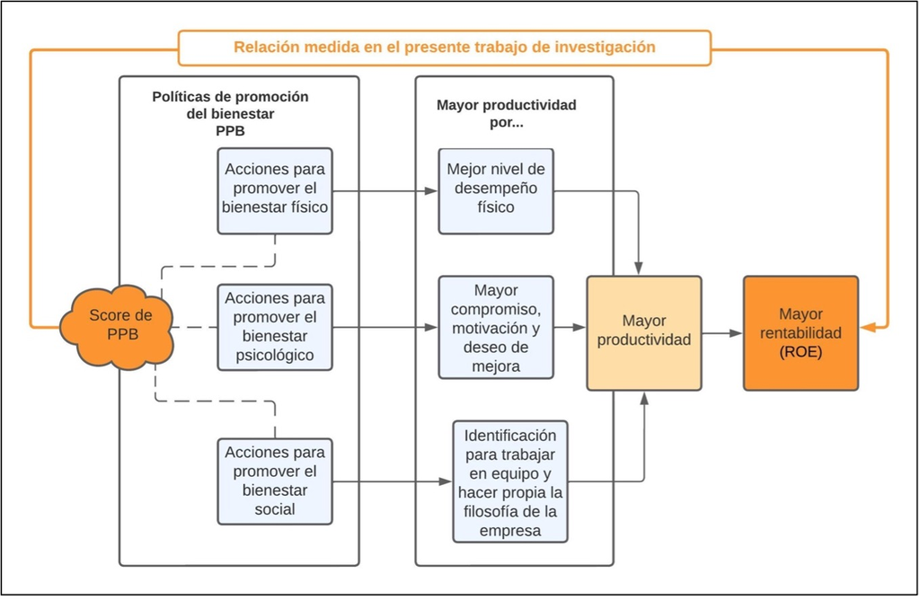

# Medición del bienestar laboral en la empresa (2 de 4)

MacKerron (2012), en un artículo propio de la *Economía laboral* sugiere que la relación bienestar laboral-productividad se da de la siguiente forma:

$$I(h(x)),\text{ }h(x):\text{Función de
felicidad o bienestar}, I(\cdot)=\text{Función de ingreso o
productividad}$$

En este trabajo se dará como dada la relación **promoción de bienestar (PPB)- bienestar laboral (felicidad)** y se probará la relación:

$$I(x)$$
En donde $x$ es la calidad de los esfuerzos (políticas) de promoción de bienestar en la empresa.

**promoción de bienestar (PPB)- productividad**

La definición de productividad se aproximará por medio de la rentabilidad o **Retorno sobre la inversión** ($ROE_{i,t}$) y s complementará la visión con el incremento del precio de la acción $\Delta\%P_{i,t}$ y la exposición al riesgo de emrcado $\beta_{i,t}$

En específico se medirá la influencia que tiene la **calidad de las políticas de promoción del bienestar laboral (PPB) en estas tres variables**:

# Medición del bienestar laboral en la empresa (3 de 4)

La calidad de las PPB se hará con la calificación de fuerza laboral (de 0 a 100 puntos) de la metodología ESG de Refinitiv (2022). Esta emplea más de 400 ítems que mide de la información pública, de redes sociales, de ONGs de empresas que cotizan en las bolsas de valores de todo el mundo.

De estos ítems interesan los 29 relativos a las políticas de ESG enfocadas a la fuerza de trabajo:

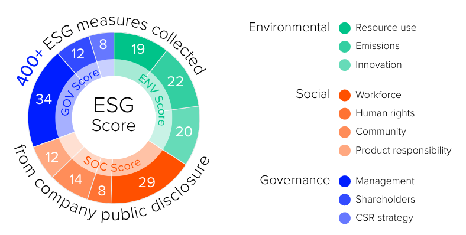

# Medición del bienestar laboral en la empresa (4 de 4)

Con estas se calcula una calificación de las políticas de bienestar laboral que va de 0 a 100.

Estas políticas de promoción de bienestar laboral para incrementar su productividad se define como **políticas laborales de alto desempeño** o *high performing working policies* ($HPWP_{i,t}$)

A mayor score o calificación de promoción de bienestar laboral $HPWP_{i,t}$, se espera una mayor rentabilidad.

# Definición de la hipótesis de trabajo

# Hipótesis de trabajo (1 de 2)

$H_1:$ *“A mayor promoción del bienestar laboral (PPB) aproximado con la calidad de las políticas de promoción de bienestar laboral $HPWP_{i,t}$, la rentabilidad $ROE_{i,t}$ se incrementa.”*

Adicional a esta posición, se medirá el beneficio que para una o un inversionista tiene el activismo en bienestar laboral. Esto llevó a demostrar las siguientes dos hipótesis:

$H_2:$ *“A mayor promoción del bienestar laboral (PPB) aproximado con la calidad de las políticas de promoción de bienestar laboral $HPWP_{i,t}$, mayor rendimiento promedio esperado en el desempeño de la acción de esa empresa ($\Delta P_{i,t}$).”*

$H_3:$ *“A mayor promoción del bienestar laboral (PPB) aproximado con la calidad de las políticas de promoción de bienestar laboral $HPWP_{i,t}$, los inversionistas tienen una menor exposición al riesgo de mercado ($\beta_{i,t}$).”*

Estas 3 hipótesis se aplicarán, de manera comparativa, en una muestra de empresas que cotizan en la Bolsa Mexicana de Valores, así como de las empresas miembro del índice Eurostoxx 50.

El comparativo se hace porque interesa emplear los mercados busátiles europeos como referencia o *benchmark*, ante la legislación fuertemente enfocada a mejorar el bienestar laboral, en estos países.

# Hipótesis de trabajo (2 de 2)

Esto llega a la siguiente ecuación general para $H_1$:

$$ROE_{i,t}=\alpha+\beta \cdot
HPWP_{i,t}+\sum_{f=1}^F\gamma_f\cdot
Fin_{f,i,t}+\sum_{c=1}^C\gamma_c\cdot
Cond_{c,i,t}+\varepsilon_{i,t}$$
Se refuta la posición de la Economía clásica si $\beta\geq 0$ y se acepta la hipótesis de trabajo $H_1$ si $\beta>0$.

Para $H_1$ se tiene la siguiente ecuación:

$$\Delta\% P_{i,t}=\alpha+\beta \cdot
HPWP_{i,t}+\sum_{f=1}^F\gamma_f\cdot
Fin_{f,i,t}+\sum_{c=1}^C\gamma_c\cdot
Cond_{c,i,t}+\varepsilon_{i,t}$$

También se refuta la posición de la Economía clásica si $\beta\geq 0$ y se acepta la hipótesis de trabajo $H_2$ si $\beta>0$.

Para $H_2$ se tiene la siguiente ecuación:

$$\beta_{i,t}=\alpha+b \cdot
HPWP_{i,t}+\sum_{f=1}^F\gamma_f\cdot
Fin_{f,i,t}+\sum_{c=1}^C\gamma_c\cdot
Cond_{c,i,t}+\varepsilon_{i,t}$$

Se acepta la hipótesis de trabajo $H_3$ si $b<0$.

# Implicaciones prácticas de la comprobación de hipótesis

1. Si las hipótesis se demuestran como verdaderas, se tendrán elementos fuertes para promover la inversión ESG enfocada primordialmente en empresas con altos estándares de promoción de bienestar laboral (un score $HPWP_{i,t}$ alto).
2. Esto permitiría que, conforme la tendencia y agenda social marca, se incentivara a las empresas a mejorar el bienestar laboral. Esto en la parte del costo del capital, ya que generaría mayor interés en invertir una empresa con alto $HPWP_{i,t}$ sin menoscabo de la rentabilidad para los inverisonistas.
3. Se contribuirá al debate de la teoría económica clásica v.s. la de la responsabilidad social. Si hay evidencia de que se incrementa la rentabilidad o, al menos, no se disminuye al promover el bienestar laboral, se refuta la posición clásica (Friedman). 4.Se darán elementos cuantitativos para que las y los inversionistas puedan invertir **solamente** en empresas con alta calidad en la promoción de bienestar laboral ($HPWP_{i,t}$). Esto sin menoscabo de su rentabilidad o exposición al riesgo.

# Revisión de literatura

# Felicidad laboral y productividad (1 de 2)

Estos trabajos encuentran una maximización de la felicidad y sustentan el supuesto de la relación $I(x)$:

- Da Costa et al. (2020) (Argentina, Brasil, Chile y Uruguay).
- Pradenas et al. (2021) (Chile).
- Wright et al. (2007) (EEUU).
- Oswald et al. (2015) (universidades inglesas: los individuos sonmás productivos con estímulos positivos y menos con noticias malas o catastróficas).
- Ravina-Ripoll et al. (2021) (revisión bibliográfica de trabajos que efectivamente demuestran esta relación directa entre bienestar o condiciones que lo fomentan y el nivel de productividad).
- Magnier-Watanabe et al. (2017) (caso japonés).
- Chanda y Goyal (2020) (caso de India).
- Kessler et al. (2020) **Encuentra una relación significativa y negativa pero, al controlar por tamaño de empresa, se sostiene la hipótesis** (Italia). Este trabajo sugiere incorporamos tamaño de empresa en las pruebas de la investigación.

# Felicidad laboral y precio de la acción en el mercado

- Edmans (2012), Li y Zhang (2013), y Goetzel et al. (2019): Se genera *alpha* (rendimiento en el precio superior al del resto del mercado) en acciones de EEUU y Reino Unido, al emplear el modelo de Carhart (1997) si se promueve el bienestar laboral.
- Goetzel et al. (2019): Invertir en un portafolio de empresas $HPWP_{i,t}$ lleva a un desempeño superior al del S&P 500.

# Fase experimental (prueba de las hipótesis)

# Extracción y procesamiento de datos (1 de 6): Universo de acciones de la muestra

Para realizar las pruebas se extrajo un dato panel de datos anuales desde el año 2011 al 2022.

Para el caso mexicano se extrajeron las empresas miembro del índice **Refinitiv Mexico price return index**.

Para el europeo las empresas miembro del índice **Eurostoxx 50**.

# Extracción y procesamiento de datos (2 de 6): Variables de la empresa estudiadas

Se extrajo información de las siguientes variables de cada empresa:

1. Retorno de la inversión $ROE_{i,t}$ como aproximación de la productividad de la empresa:
   $$ROe_{i,t}=\frac{\text{Utilidad neta de la empresa
   i en el año }t}{\text{capital contable promedio trimestral de la empresa
   i en el año }t}$$
2. La variación porcentual anual $\Delta\%P_{i,t}$ del precio de la acción en el año.
3. El nivel de riesgo de mercado $\beta_{i,t}$

4.Score ESG con controversias $ESG_{i,t}$, estimado con la metodología ESG de Refinitiv (2022). 5. Score del pilar ambiental $ENV_{i,t}$, estimado con la metodología ESG de Refinitiv (2022). 6. Score del pilar social $SOC_{i,t}$, estimado con la metodología ESG de Refinitiv (2022). 7. Score del pilar de gobierno corporativo $GOV_{i,t}$, estimado con la metodología ESG de Refinitiv (2022). 8.Score de fuerza de trabajol $HPWP_{i,t}$, estimado con la metodología ESG de Refinitiv (2022) y como aproximación de la calidad de las políticas y esfuerzos de promoción de bienestar laboral (PPB). 9. Nivel de apalancamiento $leverage_{i,t}$ como *proxy* de la salud financiera de la empresa.

# Extracción y procesamiento de datos (2 de 6): Variables de mercado

Se extrajeron o estimaron estas variables de mercado como factores que controlan el efecto ya sea de precio o de desempeño (fundamental o de mercado) de la empresa:

1. El factor de Carhart que controla el tamaño (menor menos mayoro $SMB_{i,t}$) de la empresa. Se calculó con los índices MSCI small y large cpitalization.
2. El factor de Carhart que controla el estilo de empresa (valor v.s. crecimiento). Esto al restar el desempeño de las empresas de mayor relación $P/E$ menos la de menor $P/E$ ($HML_{i,t}$).
3. El factor de momentum $MOM_{i,t}$ o inercia del precio de la acción.
4. El índice de volatilidad implícita ($VIX_t$) de las opciones ATM e ITM del índice S&P 500.
5. Para el caso europeo, su contraparte europea $VSTOXX_t$ para las opciones del STOXX 50.
6. El índice de volatilidad implícita de las opciones ATM e ITM de los futuros de la mezcla WTI del petróleo.

# Extracción y procesamiento de datos (3 de 6): Variables conductistas o de sentimiento de mercado

También se incorporaron factores conductistas como es la sensibilidad que el precio de la acción o la rentabilidad de la empresa (o su riesgo de mercado) tienen ante el sentimiento cambiante en estas variables (Baker et al., 2019; Baker et al., 2020, 2021; Bloom, 2009):

1. Nivel de incertidumbre en relación a la política económica mundial $econUncertaintyGlobal_{i,t}$.
2. Nivel de miedo o incertidumbre derivado de noticias epidémicas o pandémicas $pandemicVolatility_{i,t}$.
3. Nivel de incertidumbre en mercados financieros de EEUU en posts de Twitter $twitter_{i,t}$

# Extracción y procesamiento de datos (4 de 6): Universo de acciones de la muestra

La muestra de empresas con las variables anteriores es la siguiente para cada región de interés:

- Europa: Un panel no balanceado de datos de 3 a 12 años de longitud y 50 empresas de amplitud (panel corto y ancho).
- México: Un panel no balanceado de datos de 1 a 12 años de longitud y 52 empresas de amplitud (panel corto y ancho).

# Extracción y procesamiento de datos (5 de 6): Universo de acciones de la muestra

Se estimaron los siguientes modelos de regresión de datos panel:

1. Modelo de Pool de datos con el método de MCO y estimadores robustos de errores estándar de Newey-West para reducir el impacto de hetersocedasticidad y correlación serial.
2. Modelo de efectos fijos entre grupos (*within*) con los mismos estimadores robustos de $\sigma_{\bar{\beta}},\sigma_{\bar{\gamma}},\sigma_{\bar{\theta}}$. Esto se hizo para permitir efectos por empresa.
3. El modelo de efectos aleatorios con el método de Swammy-Arora (1972) y estimadores robustos de $\sigma_{\bar{\beta}},\sigma_{\bar{\gamma}},\sigma_{\bar{\theta}}$. Esto para relajar el supuesto de correlación de residuales entre grupos y permitir que los efectos se deban a una cuestión de muestreo aleatorio.

De estos 3 modelos de datos panel se siguió la siguiente secuencia para determinar el más adecuado a la myestra:

1. Se comparó el modelo de pool v.s. el de efectos fijos con la prueba F. Si el p-value es pequeño se acepta el empleo del segundo modelo.
2. De ser factible el modelo de efectos aleatorios, se utiliza la prueba de Hausman (1978) para comparar el modelo de efectos fijos v.s. el de aleatorios. Si el p-value es grande, se acepta el uso del segundo.

# Extracción y procesamiento de datos (6 de 6): Ecuaciones estimadas

Para las hipótesis $H_1$ y $H_2$ se utilizaron todas las regresoras.

Para evitar multicolinealidad, en las 3 pruebas de hipótesis se siguió la siguiente secuencia de uso de calificaciones de ESG:

1. Un modelo con las variables de mercado o apalancamiento según sea el caso.
2. El modelo anterior agregando las variables conductistas o de sentimiento de mercado.
3. Un modelo solamente con el score $ESG_{i,t}$.
4. Un modelo con las calificaciones del pilar ambiental y de gobierno corporativo $ENV_{i,t}$, $GOV_{i,t}$ y con el score de las políticas laborales o promoción del bienestar $HPW_{i,t}$ (que forma parte del pilar social). **Nota:** no se incluye el pilar social para evitar multicolinealidad.
5. El modelo anterior pero controlando el efecto de la $\beta$ del score $HPW_{i,t}$ por sector económico (tipo de industria según la clasificación de negocio de Refinitiv (2020)): $\beta\cdot HPWP_{i,t}\times I_{SE}$. En donde $I_{SE}=1$ si la empresa es del sector económico o $I_{SE}=0$ en caso contrario.

Se corrieron 5 ecuaciones de regresión. La última es para evitar el efecto de “paradoja de Simpson” en donde los sectores con $\beta$ negativa sumen o se eliminen con los de $\beta$ positiva y se pierda la significancia en lo general.

# Software utilizado

Se utilizó el lenguaje de programación R con la librería **plm** (Croissant y Millo, 2008) y la función [**panelAnalysis()**](https://github.com/OscarVDelatorreTorres/panelAnalysis) (De la Torre-Torres, 2023) para realizar la secuencia de regresiones.

# Resultados del caso Europeo

# Caso europeo (1 de 6): Resumen por región del continente

Data summary by continent and geographic region

| region | minorRegion | marketValue | numCompanies | esgScore | HPWPScore | marketValueProp | numCompaniesProp |
| --- | --- | --- | --- | --- | --- | --- | --- |
| Europe | Northern Europe | 3,255.77 | 13 | 84.66 | 92.04 | 46.04 | 26.53 |
| Europe | Southern Europe | 169.62 | 3 | 89.91 | 97.80 | 2.40 | 6.12 |
| Europe | Western Europe | 3,645.66 | 33 | 82.12 | 94.63 | 51.56 | 67.35 |
|  | Total or mean values | 7,071.05 | 49 | 85.57 | 94.82 | 100.00 | 100.00 |

Source: Own elaboration with data of Refinitiv

# Caso europeo (2 de 6): Resumen de datos por país

Data summary by region and country of HQ

| minorRegion | countryHQ | marketValue | numCompanies | esgScore | HPWPScore | marketValueProp | numCompaniesProp |
| --- | --- | --- | --- | --- | --- | --- | --- |
| Northern Europe | Denmark | 2,138.64 | 1 | 81.86 | 87.22 | 30.25 | 2.04 |
| Northern Europe | United Kingdom | 1,117.13 | 12 | 84.90 | 92.44 | 15.80 | 24.49 |
| Southern Europe | Italy | 51.14 | 1 | 92.00 | 99.58 | 0.72 | 2.04 |
| Southern Europe | Spain | 118.48 | 2 | 88.86 | 96.92 | 1.68 | 4.08 |
| Western Europe | Belgium | 113.62 | 1 | 78.57 | 73.71 | 1.61 | 2.04 |
| Western Europe | France | 1,385.64 | 12 | 78.08 | 95.42 | 19.60 | 24.49 |
| Western Europe | Germany | 600.79 | 8 | 89.16 | 96.57 | 8.50 | 16.33 |
| Western Europe | Netherlands | 330.53 | 3 | 74.29 | 90.11 | 4.67 | 6.12 |
| Western Europe | South Africa | 152.48 | 1 | 58.02 | 84.41 | 2.16 | 2.04 |
| Western Europe | Switzerland | 1,062.60 | 8 | 87.53 | 97.07 | 15.03 | 16.33 |
| Total or mean values |  | 7,071.05 | 49 | 81.33 | 91.34 | 100.00 | 100.00 |

Source: Own elaboration with data of Refinitiv

# Caso europeo (3 de 6): Resumen de datos sector de negocio

Sample summary by business sector

| Sector de negocio | Valor de mercado | ROE | Calif. ESG | Pilar amb. | Pilar soc. | Pilar Gob. | Calif. PPB |
| --- | --- | --- | --- | --- | --- | --- | --- |
| Automobiles & Auto Parts | 54.74 | 15.47 | 92.92 | 92.37 | 94.31 | 91.32 | 98.22 |
| Banking & Investment Services | NA | 8.07 | 83.77 | 91.38 | 79.48 | 87.64 | 88.30 |
| Chemicals | 56.76 | 15.21 | 77.56 | 74.79 | 76.09 | 84.93 | 93.32 |
| Cyclical Consumer Products | 87.24 | 19.43 | 57.81 | 62.99 | 63.67 | 43.71 | 86.65 |
| Energy - Fossil Fuels | 100.91 | 11.90 | 86.95 | 88.16 | 88.12 | 83.10 | 94.05 |
| Financial Technology (Fintech) & Infrastructure | 41.01 | 27.57 | 44.79 | 30.71 | 31.73 | 58.48 | 65.91 |
| Food & Beverages | 128.51 | 26.01 | 79.63 | 82.43 | 79.82 | 76.38 | 87.19 |
| Healthcare Services & Equipment | 40.67 | 10.42 | 66.16 | 58.65 | 68.73 | 67.88 | 82.61 |
| Industrial & Commercial Services | NA | 37.91 | 79.81 | 84.06 | 69.81 | 85.53 | 95.05 |
| Industrial Goods | 46.71 | 20.55 | 71.64 | 76.62 | 76.53 | 61.66 | 88.92 |
| Insurance | 56.18 | 10.89 | 78.23 | 84.05 | 76.12 | 81.06 | 83.38 |
| Mineral Resources | NA | 17.62 | 82.51 | 82.23 | 87.11 | 75.37 | 90.27 |
| Personal & Household Products & Services | NA | 22.58 | 82.86 | 86.01 | 84.73 | 77.30 | 87.29 |
| Pharmaceuticals & Medical Research | NA | 39.54 | 85.11 | 83.15 | 91.37 | 77.19 | 93.36 |
| Retailers | 41.96 | 17.56 | 75.64 | 96.77 | 89.46 | 49.74 | 98.96 |
| Software & IT Services | 98.68 | 17.85 | 81.16 | 70.79 | 82.96 | 83.53 | 89.31 |
| Technology Equipment | 89.55 | 28.57 | 68.45 | 54.04 | 81.87 | 63.60 | 91.47 |
| Telecommunications Services | 66.67 | 14.03 | 78.52 | 81.61 | 84.27 | 64.61 | 92.63 |
| Transportation | 37.81 | 20.49 | 81.88 | 78.89 | 89.87 | 75.08 | 98.52 |
| Utilities | 43.02 | 11.93 | 80.61 | 79.85 | 85.76 | 75.21 | 83.30 |

Source: Own elaboration with data of Refinitiv

# Caso europeo (4 de 6): Tabla de regresiones para $ROE_{i,t}$

|  | *Dependent variable:* |  |  |  |  |
| --- | --- | --- | --- | --- | --- |
|  | roeW |  |  |  |  |
|  | (1) | (2) | (3) | (4) | (5) |
| leverage | 0.2725* | 0.3155* | 0.3235** | 0.3351** | 0.4126** |
| VIX | -0.1831** | 3.1165** | 3.1649** | 2.9195** | 2.3453* |
| VSTOXXVIX | 0.1774** | 0.1572* | 0.1656* | 0.1739** | 0.1364* |
| OILVIX | -0.0299 | -0.1122* | -0.1146* | -0.1210* | -0.0822 |
| econUncertaintyGlobal |  | 0.0761** | 0.0780** | 0.0696* | 0.0493 |
| pandemicVolatility |  | -1.0727** | -1.0749** | -0.9829** | -0.7656* |
| geoPoliticalRisk |  | -0.2011** | -0.2025** | -0.1894* | -0.1471 |
| FXVolatility |  | 25.5911*** | 25.0762*** | 23.5460** | 17.6976* |
| CommodityVolatility |  | -7.1031** | -7.2058*** | -6.5737** | -5.3791* |
| twitter |  | -0.0488*** | -0.0536*** | -0.0465** | -0.0450** |
| esgScore |  |  | -0.1220** |  |  |
| envScoreN |  |  |  | -0.0416 | -0.0705* |
| govScoreN |  |  |  | -0.0368 | -0.0861*** |
| HPWPScore |  |  |  | 0.0056 | -0.2948 |
| HPWPScore:I(businessSector)Banking | Investment Services |  |  |  |  |
| HPWPScore:I(businessSector)Chemicals |  |  |  |  | 0.7089 |
| HPWPScore:I(businessSector)Cyclical Consumer Products |  |  |  |  | 0.3167 |
| HPWPScore:I(businessSector)Energy - Fossil Fuels |  |  |  |  | 0.0725 |
| HPWPScore:I(businessSector)Financial Technology (Fintech) | Infrastructure |  |  |  |  |
| HPWPScore:I(businessSector)Food | Beverages |  |  |  |  |
| HPWPScore:I(businessSector)Healthcare Services | Equipment |  |  |  |  |
| HPWPScore:I(businessSector)Industrial | Commercial Services |  |  |  |  |
| HPWPScore:I(businessSector)Industrial Goods |  |  |  |  | 0.3335 |
| HPWPScore:I(businessSector)Insurance |  |  |  |  | 0.4237 |
| HPWPScore:I(businessSector)Mineral Resources |  |  |  |  | 1.0756 |
| HPWPScore:I(businessSector)Personal | Household Products | Services |  |  |  |
| HPWPScore:I(businessSector)Pharmaceuticals | Medical Research |  |  |  |  |
| HPWPScore:I(businessSector)Retailers |  |  |  |  | 10.8196* |
| HPWPScore:I(businessSector)Software | IT Services |  |  |  |  |
| HPWPScore:I(businessSector)Technology Equipment |  |  |  |  | 2.8559 |
| HPWPScore:I(businessSector)Telecommunications Services |  |  |  |  | 0.3962 |
| HPWPScore:I(businessSector)Transportation |  |  |  |  | 0.2378 |
| HPWPScore:I(businessSector)Utilities |  |  |  |  | 0.2762 |
| Model | Fixed eff. | Fixed eff. | Fixed eff. | Fixed eff. | Fixed eff. |
| LLF | -1301.7851 | -1295.3329 | -1293.8373 | -1293.6428 | -1261.1314 |
| AIC | 3277.5701 | 3252.6659 | 3247.6747 | 3243.2855 | 3140.2627 |
| BIC | 3070.7513 | 3352.8215 | 3378.9801 | 3428.5889 | 3593.1751 |
| HQIC | 2823.7216 | 3142.7954 | 3164.905 | 3205.1973 | 3290.3904 |
| Observations | 391 | 391 | 391 | 391 | 391 |
| R<sup>2</sup> | 0.0468 | 0.0777 | 0.0847 | 0.0857 | 0.2257 |
| Adjusted R<sup>2</sup> | -0.1032 | -0.0867 | -0.0817 | -0.0872 | 0.0228 |
| F Statistic | 4.1332*** (df = 4; 337) | 2.7890*** (df = 10; 331) | 2.7776*** (df = 11; 330) | 2.3635*** (df = 13; 328) | 2.8153*** (df = 32; 309) |
| *Note:* | *p<0.1; **p<0.05; ***p<0.01 |  |  |  |  |

# Caso europeo (5 de 6): Tabla de regresiones para $\Delta \% P_{i,t}$

|  | *Dependent variable:* |  |  |  |  |
| --- | --- | --- | --- | --- | --- |
|  | priceChangeW |  |  |  |  |
|  | (1) | (2) | (3) | (4) | (5) |
| MKT | 0.6859*** | 0.3346 | 0.3328 | 0.3333 | 0.2660 |
| SMB | -0.2091 | -1.7380** | -1.7683** | -1.9111** | -1.8020** |
| HML | 0.5219*** | 1.7799*** | 1.7608*** | 1.7633*** | 1.8072*** |
| MOM | 0.1784 | 2.2800*** | 2.2347*** | 2.2681*** | 2.3396*** |
| leverage | -0.1825** | -0.1779** | -0.1375* | -0.1351* | -0.2607* |
| VIX | 0.1844 | 8.1130*** | 7.8798*** | 8.0135*** | 7.9709*** |
| VSTOXXVIX | -0.2391 | 0.0460 | 0.0119 | -0.0181 | 0.0168 |
| OILVIX | 0.1338 | -0.0797 | -0.0619 | -0.0265 | -0.0440 |
| econUncertaintyGlobal |  | -0.2115*** | -0.2005** | -0.2083*** | -0.1980** |
| pandemicVolatility |  | -3.5915*** | -3.4713*** | -3.5005*** | -3.5752*** |
| twitter |  | 0.0157 | -0.0031 | 0.0043 | 0.0636 |
| esgScore |  |  | -0.2320*** |  |  |
| envScoreN |  |  |  | -0.0155 | 0.0390 |
| govScoreN |  |  |  | -0.1366*** | 0.0510 |
| HPWPScore |  |  |  | 0.0383 | -2.6142 |
| I(businessSector)Banking | Investment Services |  |  |  |  |
| I(businessSector)Chemicals |  |  |  |  | -182.8939 |
| I(businessSector)Cyclical Consumer Products |  |  |  |  | -316.9045 |
| I(businessSector)Energy - Fossil Fuels |  |  |  |  | -228.4678 |
| I(businessSector)Financial Technology (Fintech) | Infrastructure |  |  |  |  |
| I(businessSector)Food | Beverages |  |  |  |  |
| I(businessSector)Healthcare Services | Equipment |  |  |  |  |
| I(businessSector)Industrial | Commercial Services |  |  |  |  |
| I(businessSector)Industrial Goods |  |  |  |  | -246.8182 |
| I(businessSector)Insurance |  |  |  |  | -257.8452 |
| I(businessSector)Mineral Resources |  |  |  |  | -230.2270 |
| I(businessSector)Personal | Household Products | Services |  |  |  |
| I(businessSector)Pharmaceuticals | Medical Research |  |  |  |  |
| I(businessSector)Retailers |  |  |  |  | 919.2508 |
| I(businessSector)Software | IT Services |  |  |  |  |
| I(businessSector)Technology Equipment |  |  |  |  | -237.6856 |
| I(businessSector)Telecommunications Services |  |  |  |  | -365.7836 |
| I(businessSector)Transportation |  |  |  |  | -872.3033 |
| I(businessSector)Utilities |  |  |  |  | -258.8511 |
| HPWPScore:I(businessSector)Banking | Investment Services |  |  |  |  |
| HPWPScore:I(businessSector)Chemicals |  |  |  |  | 1.7715 |
| HPWPScore:I(businessSector)Cyclical Consumer Products |  |  |  |  | 3.4499 |
| HPWPScore:I(businessSector)Energy - Fossil Fuels |  |  |  |  | 2.2720 |
| HPWPScore:I(businessSector)Financial Technology (Fintech) | Infrastructure |  |  |  |  |
| HPWPScore:I(businessSector)Food | Beverages |  |  |  |  |
| HPWPScore:I(businessSector)Healthcare Services | Equipment |  |  |  |  |
| HPWPScore:I(businessSector)Industrial | Commercial Services |  |  |  |  |
| HPWPScore:I(businessSector)Industrial Goods |  |  |  |  | 2.5672 |
| HPWPScore:I(businessSector)Insurance |  |  |  |  | 2.5363 |
| HPWPScore:I(businessSector)Mineral Resources |  |  |  |  | 2.3951 |
| HPWPScore:I(businessSector)Personal | Household Products | Services |  |  |  |
| HPWPScore:I(businessSector)Pharmaceuticals | Medical Research |  |  |  |  |
| HPWPScore:I(businessSector)Retailers |  |  |  |  | -9.1206 |
| HPWPScore:I(businessSector)Software | IT Services |  |  |  |  |
| HPWPScore:I(businessSector)Technology Equipment |  |  |  |  | 2.5946 |
| HPWPScore:I(businessSector)Telecommunications Services |  |  |  |  | 3.8256 |
| HPWPScore:I(businessSector)Transportation |  |  |  |  | 8.8979 |
| HPWPScore:I(businessSector)Utilities |  |  |  |  | 2.6874 |
| Constant | 4.4219 | -88.3318*** | -65.0384** | -79.5182** | 152.3070 |
| Model | Pool | Pool | Pool | Pool | Pool |
| LLF | -1706.6182 | -1702.7717 | -1698.7363 | -1698.2836 | -1679.2092 |
| AIC | 4173.2365 | 4159.5434 | 4149.4726 | 4144.5672 | 4030.4184 |
| BIC | 4248.1818 | 4342.3532 | 4361.8935 | 4409.3779 | 4692.4365 |
| HQIC | 4011.5047 | 4091.8606 | 4105.8105 | 4141.7464 | 4284.9986 |
| Observations | 389 | 389 | 389 | 389 | 389 |
| R<sup>2</sup> | 0.2073 | 0.2228 | 0.2387 | 0.2405 | 0.3115 |
| Adjusted R<sup>2</sup> | 0.1906 | 0.2001 | 0.2144 | 0.2121 | 0.2049 |
| F Statistic | 12.4183*** (df = 8; 380) | 9.8237*** (df = 11; 377) | 9.8263*** (df = 12; 376) | 8.4595*** (df = 14; 374) | 2.9228*** (df = 52; 336) |
| *Note:* | *p<0.1; **p<0.05; ***p<0.01 |  |  |  |  |

# Caso europeo (6 de 6): Tabla de regresiones para $\beta_{i,t}$

|  | *Dependent variable:* |  |  |  |  |
| --- | --- | --- | --- | --- | --- |
|  | waccBetaW |  |  |  |  |
|  | (1) | (2) | (3) | (4) | (5) |
| leverage | -0.0010 | 0.0004 | 0.0002 | 0.0006 | 0.0017 |
| VIX | -0.0018 | -0.0484 | -0.0494 | -0.0402 | -0.0399 |
| VSTOXXVIX | -0.0013 | -0.0037 | -0.0038 | -0.0032 | -0.0031 |
| OILVIX | -0.0002 | 0.0033 | 0.0034* | 0.0030 | 0.0028 |
| econUncertaintyGlobal |  | -0.0015 | -0.0016 | -0.0013 | -0.0013 |
| pandemicVolatility |  | 0.0111 | 0.0113 | 0.0077 | 0.0076 |
| geoPoliticalRisk |  | 0.0035 | 0.0036 | 0.0032 | 0.0032 |
| FXVolatility |  | -0.6160 | -0.6084 | -0.5836 | -0.6039* |
| CommodityVolatility |  | 0.1161 | 0.1181 | 0.0995 | 0.0998 |
| twitter |  | 0.0032*** | 0.0032*** | 0.0031*** | 0.0030*** |
| esgScore |  |  | 0.0020 |  |  |
| envScoreN |  |  |  | -0.0003 | -0.0016 |
| govScoreN |  |  |  | 0.0016* | 0.0023*** |
| HPWPScore |  |  |  | -0.0038** | -0.0400* |
| HPWPScore:I(businessSector)Banking | Investment Services |  |  |  |  |
| HPWPScore:I(businessSector)Chemicals |  |  |  |  | 0.0254 |
| HPWPScore:I(businessSector)Cyclical Consumer Products |  |  |  |  | 0.0420* |
| HPWPScore:I(businessSector)Energy - Fossil Fuels |  |  |  |  | 0.0534** |
| HPWPScore:I(businessSector)Financial Technology (Fintech) | Infrastructure |  |  |  |  |
| HPWPScore:I(businessSector)Food | Beverages |  |  |  |  |
| HPWPScore:I(businessSector)Healthcare Services | Equipment |  |  |  |  |
| HPWPScore:I(businessSector)Industrial | Commercial Services |  |  |  |  |
| HPWPScore:I(businessSector)Industrial Goods |  |  |  |  | 0.0381 |
| HPWPScore:I(businessSector)Insurance |  |  |  |  | 0.0404* |
| HPWPScore:I(businessSector)Mineral Resources |  |  |  |  | 0.0312 |
| HPWPScore:I(businessSector)Personal | Household Products | Services |  |  |  |
| HPWPScore:I(businessSector)Pharmaceuticals | Medical Research |  |  |  |  |
| HPWPScore:I(businessSector)Retailers |  |  |  |  | -0.0231 |
| HPWPScore:I(businessSector)Software | IT Services |  |  |  |  |
| HPWPScore:I(businessSector)Technology Equipment |  |  |  |  | 0.0546** |
| HPWPScore:I(businessSector)Telecommunications Services |  |  |  |  | 0.0489** |
| HPWPScore:I(businessSector)Transportation |  |  |  |  | 0.0156 |
| HPWPScore:I(businessSector)Utilities |  |  |  |  | 0.0173 |
| Constant | 1.1061*** |  |  |  |  |
| Model | Random eff. | Fixed eff. | Fixed eff. | Fixed eff. | Fixed eff. |
| LLF | 133.6386 | 165.6314 | 166.2811 | 171.0862 | 206.4678 |
| AIC | 482.7228 | 308.7373 | 305.4378 | 291.8277 | 183.0645 |
| BIC | 336.262 | 405.5645 | 432.3664 | 470.9166 | 619.8538 |
| HQIC | 89.6365 | 202.5181 | 225.4271 | 255.0168 | 327.8478 |
| Observations | 380 | 380 | 380 | 380 | 380 |
| R<sup>2</sup> | 0.0223 | 0.0385 | 0.0417 | 0.0657 | 0.2244 |
| Adjusted R<sup>2</sup> | 0.0119 | -0.1388 | -0.1385 | -0.1171 | 0.0136 |
| F Statistic | 4.4327 | 1.2801 (df = 10; 320) | 1.2634 (df = 11; 319) | 1.7141* (df = 13; 317) | 2.6947*** (df = 32; 298) |
| *Note:* | *p<0.1; **p<0.05; ***p<0.01 |  |  |  |  |

# Resultados para México

# Caso Mexicano (1 de 4): Resumen de datos por país

En la muestra del panel de datos mexicano contempló los sectores de negocio de Automobiles & Auto Parts,Banking & Investment Services,Chemicals,Consumer Goods Conglomerates,Cyclical Consumer Products,Cyclical Consumer Services,Energy - Fossil Fuels,Food & Beverages,Food & Drug Retailing,Mineral Resources,Personal & Household Products & Services,Pharmaceuticals & Medical Research,Real Estate,Retailers,Telecommunications Services,Transportation.

Data summary by business sector

| businessSector | marketValue | numCompanies | ROE | esgScore | HPWPScore | marketValueProp | numCompaniesProp |
| --- | --- | --- | --- | --- | --- | --- | --- |
| Automobiles & Auto Parts | 16,984,756,521.44 | 1 | 3.53 | 60.18 | 76.80 | 0.2536785 | 2.127660 |
| Banking & Investment Services | 780,308,837,801.52 | 6 | 19.44 | 44.53 | 60.95 | 11.6544253 | 12.765957 |
| Chemicals | 127,483,932,811.12 | 2 | 16.43 | 72.60 | 80.20 | 1.9040563 | 4.255319 |
| Consumer Goods Conglomerates | 242,092,290,384.16 | 2 | 23.05 | 29.99 | 40.62 | 3.6158075 | 4.255319 |
| Cyclical Consumer Products | 310,677,644,356.23 | 1 | 11.53 | 84.86 | 98.61 | 4.6401748 | 2.127660 |
| Cyclical Consumer Services | 80,327,357,531.92 | 2 | 31.69 | 68.79 | 87.79 | 1.1997419 | 4.255319 |
| Energy - Fossil Fuels | 26,832,094,413.00 | 1 | 38.25 | 58.01 | 59.28 | 0.4007550 | 2.127660 |
| Food & Beverages | 1,187,080,004,685.81 | 6 | 19.12 | 46.85 | 44.87 | 17.7298200 | 12.765957 |
| Food & Drug Retailing | 608,809,997,994.44 | 3 | 11.21 | 41.42 | 49.56 | 9.0929774 | 6.382979 |
| Mineral Resources | 889,707,034,740.38 | 5 | 11.59 | 53.18 | 50.70 | 13.2883593 | 10.638298 |
| Personal & Household Products & Services | 104,776,118,319.11 | 1 | 42.30 | 65.27 | 84.38 | 1.5649002 | 2.127660 |
| Pharmaceuticals & Medical Research | 17,753,120,000.00 | 1 | 13.19 | 71.75 | 95.97 | 0.2651545 | 2.127660 |
| Real Estate | 253,448,999,737.31 | 6 | 12.28 | 51.49 | 60.92 | 3.7854274 | 12.765957 |
| Retailers | 1,360,027,612,272.29 | 2 | 19.51 | 69.77 | 75.70 | 20.3129062 | 4.255319 |
| Telecommunications Services | 63,261,000,000.00 | 1 | 3.53 | 0.00 | 0.00 | 0.9448446 | 2.127660 |
| Transportation | 625,815,860,332.02 | 7 | 19.41 | 33.93 | 34.36 | 9.3469712 | 14.893617 |
| Total or mean values | 6,695,386,661,900.75 | 47 | 18.50 | 53.29 | 62.54 | 100.0000000 | 100.000000 |

Source: Own elaboration with data of Refinitiv

# Caso Mexicano (2 de 4): Tabla de regresiones para $ROE_{i,t}$

[output not shown]

# Caso Mexicano (3 de 4): Tabla de regresiones para $\Delta \% P_{i,t}$

[output not shown]

# Caso Mexicano (4 de 4): Tabla de regresiones para $\beta_{i,t}$

[output not shown]

# Corolario de resultados

### Influencia de las $HPWP_{i,t}$ en el $ROE_{i,t}$

**México**

A excepción de los setores de negocio de servicios de inversión (banca de inversión), conglomerados de bienes de consumo, bebidad, farmacias, servicios del hogar e investigación médica, todos los sectores tuvieron una relación **positiva y significativa** con el $ROE_{i,t}$. En promedio, por cada punto adicional de la calidad o calificación de las PPB ($HPWP_{i,t}$) , el $ROE_{i,t}$ se incrementó en 0.26/%.

### Influencia de las $HPWP_{i,t}$ en la variación del precio $\Delta \% P_{i,t}$

**México**

Solo sectores de bienes de consumo, servicios de consumo cíclico, recursos minerales y bienes raíces tienen una relación significativa y negativa con el precio en México

**Europa**

Ningún sector tiene una relación significativa con la variación porcentual del precio.

### Influencia de las $HPWP_{i,t}$ en la $\beta_{i,t}$

**México**

Solo los sectores de bebidas, farmacias, servicios del hogar, e investigación médica tienen una relación nula con el nivel de riesgo de mercado ($\beta_{i,t}$). El sector de productos de consumo muestra un incremento de 0.017 en el valor de la $\beta_{i,t}$ de este tipo de acciones por cada punto adicional en las $HPWP_{i,t}$.

El resto de los sectores tiene la relación esperada (inversa). Por cada punto en la calidad de las $HPWP_{i,t}$, se reduce el riesgo de mercado o $\beta_{i,t}$ en -0.037. Una mejora de solo 10 puntos reduciría el riesgo de mercado, en promedio, en -0.37.

**Europa**

Solo el sector de negocio de automóviles y autopartes tuvo la relación teóricamente esperada de $\beta_{i,t}=$-0.04 por cada punto adicional en la calificación de las PPB o $HPWP_{i,t}$.

# Conclusiones

# Conclusiones generales

Se observa que las relaciones teóricas esperadas se cumplen para la mayoría de los sectores de negocio mexicanos, siendo el caso contrario al europeo. Las posibles explicaciones son:

1. El caso europeo es uno que tiene años de legislación en promoción del bienestar laboral y la implementación de políticas de este tipo tiene un notorio desarrollo en muchos países como Francia, Italia o los países nórdicos en los que se penan muchas cuestiones que reducen el bienestar laboral (burnout o trabajar fuera de horas por ejemplo).
2. El caso mexicano es uno que tiene mucho potencial ya que se sigue en ese proceso evolutivo en las normas y prácticas de bienestar laboral. Por otro lado, al ser un país o economía emergente, tiene margen de crecimiento y muchas de sus empresas públicas tienen procesos de crecimiento que se asemejarían a los de una empresa de “**crecimiento**” en los países europeos (empresas con crecimientos en sus dividendos).
3. Al ser un país en desarrollo, México tiene margen para incentivar y motivar el activismo de inversiones e incluso legislar para que las empresas públicas puedan mejorar el bienestar laboral.

Las conclusiones se fundamentan por que en Europa, la muestra presentó un $ROE_{i,t}$ promedio de 23.7429%, un crecimiento medio anual del 9.3309% en el precio de sus acciones, una $\beta_{i,t}$ de 1.0142 y una calificación de promoción del bienestar media de 89.6721 puntos.

Para el caso mexicano las cifras son de un $ROE_{i,t}$ promedio de 14.653%, un crecimiento medio anual del 9.5973% en el precio de sus acciones, una $\beta_{i,t}$ de 0.8585 y una calificación de promoción del bienestar media de 38.0171 puntos.

Si se compara el $ROE_{i,t}$ y las $HPWP_{i,t}$, se puede apreciar una excelente área deoportunidad para mejorar la promoción del bienestar laboral en México, teniendo como beneficio la rentabilidad de la empresa. Por cada punto adicional de promoción de bienestar laboral, se incrementaría el $ROE_{i,t}$, en promedio, en un 0.26%. Si méxico igualara la calificación media de $HPWP_{i,t}$ con la de la muestra europea (un incremento de 51.65 puntos en las $HPWP_{i,t}$), se esperaría un ROE medio de 28.0833%. Una mejora del 13.4303%.

# Gracias

**Gracias por su atención**

# Referencias citadas

Baker, S. R., Bloom, N., Davis, S. J., y Kost, K. (2019). Daily infectious disease equity market volatility tracker. En *Economic policy uncertainty*. https://www.policyuncertainty.com/infectious_EMV.html

Baker, S. R., Bloom, N., Davis, S. J., y Renault, T. (2021). *Twitter-Derived Measures of Economic Uncertainty*. policyuncertainty.com.

Baker, S. R., Bloom, N., Davis, S. J., y Terry, S. J. (2020). *COVID-Induced Economic Uncertainty*. www.worlduncertaintyindex.com,

Berry, T. C., y Junkus, J. C. (2013). Socially Responsible Investing: An Investor Perspective. *Journal of Business Ethics*, *112*(4), 707-720. https://doi.org/10.1007/s10551-012-1567-0

Bloom, N. (2009). The Impact of Uncertainty Shocks. *Econometrica*, *77*(3), 623-685. https://doi.org/10.3982/ECTA6248

Carhart, M. M. (1997). On Persistence in Mutual Fund Performance. *The journal of finance*, *LII*(1), 57-82.

Chanda, U., y Goyal, P. (2020). A Bayesian network model on the interlinkage between Socially Responsible HRM, employee satisfaction, employee commitment and organizational performance. *Journal of Management Analytics*, *7*(1), 105-138. https://doi.org/10.1080/23270012.2019.1650670

Chatzitheodorou, K., Skouloudis, A., Evangelinos, K., y Nikolaou, I. (2019). Exploring socially responsible investment perspectives: A literature mapping and an investor classification. *Sustainable Production and Consumption*, *19*, 117-129. https://doi.org/10.1016/J.SPC.2019.03.006

Croissant, Y., y Millo, G. (2008). Panel data econometrics in R: The plm package. *Journal of Statistical Software*, *27*(2), 1-43. https://doi.org/10.18637/jss.v027.i02

Da Costa, S., Martínez-Moreno, E., Díaz, V., Hermosilla, D., Amutio, A., Padoan, S., Méndez, D., Etchebehere, G., Torres, A., Telletxea, S., y García-Mazzieri, S. (2020). Belonging and Social Integration as Factors of Well-Being in Latin America and Latin Europe Organizations. *Frontiers in Psychology*, *11*. https://www.frontiersin.org/articles/10.3389/fpsyg.2020.604412

De la Torre-Torres, O. V. D. la T. (2023). *panelAnalysis V. 1.0 (beta)*. https://github.com/OscarVDelatorreTorres/panelAnalysis

Edmans, A. (2012). The Link Between Job Satisfaction and Firm Value, With Implications for Corporate Social Responsibility. *Academy of Management Perspectives*, *26*(4), 1-19. https://doi.org/10.5465/amp.2012.0046

Freeman, E. (1984). *Strategic management: A stakeholder approach*. Cambridge university press.

Freeman, R. E. (1994). The Politics of Stakeholder Theory: Some Future Directions. *Business Ethics Quarterly*, *4*(4), 409-421. https://doi.org/10.2307/3857340

Friedman, M. (2007). The Social Responsibility of Business Is to Increase Its Profits. En *Corporate Ethics and Corporate Governance* (pp. 173-178). Springer Berlin Heidelberg. https://doi.org/10.1007/978-3-540-70818-6_14

Goetzel, R. Z., Fabius, R., Roemer, E. C., Kent, K. B., Berko, J., Head, M. A., y Henke, R. M. (2019). The Stock Performance of American Companies Investing in a Culture of Health. *American Journal of Health Promotion*, *33*(3), 439-447. https://doi.org/10.1177/0890117118824818

Grant, A. M., Christianson, M. K., y Price, R. H. (2007). Happiness, Health, or Relationships? Managerial Practices and Employee Well-Being Tradeoffs. *Academy of Management Perspectives*, *21*(3), 51-63. https://doi.org/10.5465/amp.2007.26421238

Hausman, J. A. (1978). Specification tests in econometrics. *Econometrica*, *46*(6), 1251-1271. https://doi.org/10.2307/1913827

Kessler, S. R., Lucianetti, L., Pindek, S., Zhu, Z., y Spector, P. E. (2020). Job satisfaction and firm performance: Can employees’ job satisfaction change the trajectory of a firm’s performance? *Journal of Applied Social Psychology*, *50*(10), 563-572. https://doi.org/10.1111/jasp.12695

Li, L., y Zhang, C. (2013). *Happiness and Alpha* [{SSRN} {Scholarly} {Paper}]. https://doi.org/10.2139/ssrn.2225795

MacKerron, G. (2012). Happiness Economics from 35 000 Feet. *Journal of Economic Surveys*, *26*(4), 705-735. https://doi.org/10.1111/j.1467-6419.2010.00672.x

Magnier-Watanabe, R., Uchida, T., Orsini, P., y Benton, C. (2017). Organizational virtuousness and job performance in Japan: does happiness matter? *International Journal of Organizational Analysis*, *25*(4), 628-646. https://doi.org/10.1108/IJOA-10-2016-1074

Misselbrook, D. (2014). W is for Wellbeing and the WHO definition of health. *British Journal of General Practice*, *64*(628), 582-582. https://doi.org/10.3399/bjgp14X682381

Oswald, A. J., Proto, E., y Sgroi, D. (2015). Happiness and Productivity. *Journal of Labor Economics*, *33*(4), 789-822. https://doi.org/10.1086/681096

Pradenas, D., Oyanedel, J. C., Costa, S. da, Rubio, A., y Páez, D. (2021). Subjective Well-Being and Its Intrinsic and Extrinsic Motivational Correlates in High Performance Executives: A Study in Chilean Managers Empirically Revisiting the Bifactor Model. *International Journal of Environmental Research and Public Health*, *18*(15), 8082. https://doi.org/10.3390/ijerph18158082

Ravina-Ripoll, R., Nunez-Barriopedro, E., Almorza-Gomar, D., y Tobar-Pesantez, L.-B. (2021). Happiness Management: A Culture to Explore From Brand Orientation as a Sign of Responsible and Sustainable Production. *Frontiers in Psychology*, *12*, 727845. https://doi.org/10.3389/fpsyg.2021.727845

Refinitiv. (2020). The Refinitiv business classification. En *Refinitiv Business classification*. https://www.refinitiv.com/content/dam/marketing/en_us/documents/quick-reference-guides/trbc-business-classification-quick-guide.pdf

Refinitiv. (2022). Environmental, social and governance scores from Refinitiv. En *ESG scores*. https://www.refinitiv.com/content/dam/marketing/en_us/documents/methodology/refinitiv-esg-scores-methodology.pdf

Swamy, P. A. V. B., y Arora, S. S. (1972). The Exact Finite Sample Properties of the Estimators of Coefficients in the Error Components Regression Models. *Econometrica*, *40*(2), 261. https://doi.org/10.2307/1909405

UNEP. (2005). *A legal frameworks for the integration od environmental, social and governance issues into institutional investment*. https://www.unepfi.org/fileadmin/documents/freshfields_legal_resp_20051123.pdf

Wright, T. A., Cropanzano, R., y Bonett, D. G. (2007). The moderating role of employee positive well being on the relation between job satisfaction and job performance. *Journal of Occupational Health Psychology*, *12*(2), 93-104. https://doi.org/10.1037/1076-8998.12.2.93